# question 4

```python
def find2s(number):
    col = []
    for i in range(number, 0, -1):
        if (number - i >= 0 and i & (i - 1) == 0):
            number -= i
            col.append(i)
    return col
def FindMin(graph, graph2):
    number = len(graph2)
    finalgraph = []
    for i in range(number):
        col = []
        for j in range(number):
            list1 = graph[i]
            list2 = []
            for m in range(number):
                list2.append(graph2[m][j])
            numbermin = 0
            first = True
            for k in range(number):
                if list1[k] == 'inf' or list2[k] == 'inf':
                    continue
                elif list1[k] == 0 or list2[k] == 0:
                    continue
                else:
                    if (first):
                        numbermin = list1[k] + list2[k]
                        first = False
                    else:
                        numbermin = min(numbermin, list1[k]+list2[k])
            if numbermin == 0:
                col.append(float('inf'))
            else:
                col.append(numbermin)
        finalgraph.append(col)
    return finalgraph


def makemartix(graph, goal):
    if (goal % 2 == 0 and goal/2 >= 1):
        mm = makemartix(graph, int(goal/2))
        return FindMin(mm, mm)
    else:
        return graph

print("how many vertices do you have ?")
number = int(input())
print()
print("write inf for no path between 2 vertices")
graph = []
for i in range(number):
    vorodi = input().split(" ")
    graph.append(vorodi)
for i in range(number):
    for j in range(number):
        if(graph[i][j] == "inf"):
            graph[i][j] = float('inf')
        else:
            graph[i][j]  = int(graph[i][j])
print("graph is :")
print(graph)
print()
print()
print("graph martabe chand ?")
tool = int(input())
array = find2s(tool)
array.reverse()
storage = {}
for i in range(len(array)):
    storage[i] = makemartix(graph, array[i])
hasel = storage[0]
for i in range(1,len(storage)):
    hasel = FindMin(storage[i], hasel)
print(hasel)
```

```
how many vertices do you have ?
3

write inf for no path between 2 vertices
0 3 9
inf 0 5
1 7 0
graph is :
[[0, 3, 9], [inf, 0, 5], [1, 7, 0]]


graph martabe chand ?
3
[[9, 13, 19], [inf, 9, 15], [11, 17, 9]]
```

بهینه سازی که در این سوال انجام شده بدین شکل هستش که برای حساب کردن هر مسیر ابتدا مرتبه ماتریس خواسته شده از کاربر گرفته میشه و پس از اینکه عدد دریافت شده به عدد هایی از توان ۲ تبدیل شدند مشخص میشود که نیاز به چه ماتریس هایی برای ساخت ماتریس نهایی هستش

این کار در تابع زیر انجام میشود

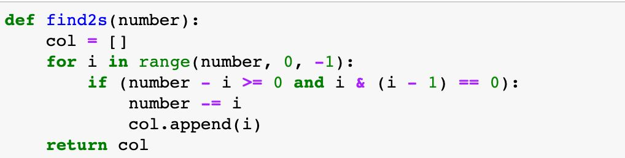

برای مثال اگر ورودی ۱۳ داشته باشیم لیست به صورت ۸ ، ۴ ، ۱ برگردانده میشود

و برای ساخت هر کدام از نکته مطرح شده در صورت سوال استفاده میشود پس برای پیاده سازی از یک تابع بازگشتی استفاده میکنیم که شرط پایه ان رسیدن به مرتبه ۱ باشد و برای ساخت مرتبه های از توان ۲ از گراف توان پایین تر استفاده کند

کد تابع بازگشتی بدین شکل می باشد

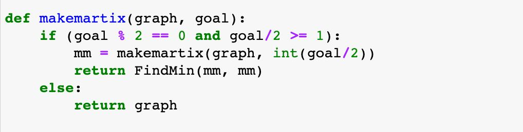

در پایان هر مسیر ساخته شده از مرتبه های توان ۲ با هم ضرب میشوند تا درنهایت گراف با مرتبه خواسته شده تشکیل شود

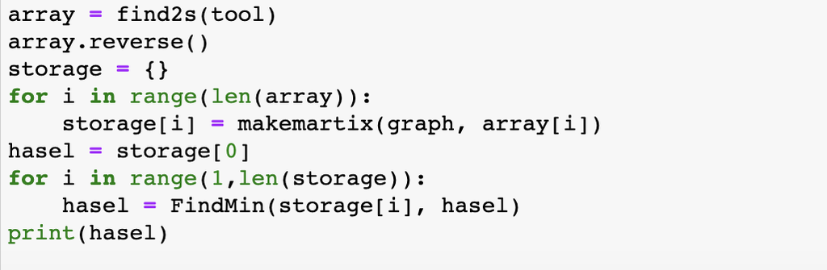

پایان